# NFPanNET scRNA-seq Endocrine Cells

Jia-Juan Tu

# 1 Import library

```r
#remove(list= ls())
library(Seurat)
library(RColorBrewer)
library(ggplot2)
library(ggthemes)
library(scatterpie)
library(cowplot)
library(gridExtra)
library(viridis)
library(ggpubr)
library(rstatix)
library(RColorBrewer)
library(stringr)
library(ggsignif)
library(clusterProfiler)
library(org.Hs.eg.db)
library(enrichplot)
library(DESeq2)
library(survival)
library(survminer)
```

# 2 Define color for cell type or samples

```r
colPar <- c("#B44145","#983C90","#565FAD","#3983C0","#6AB9D8","#227046","#98B660","#DBD177","#CEAC3B","#D68141","#897738","#905F31")
```

# 3 load Raw and extract endocrine cells

```r
obj_merged <- readRDS("./Data/10Patients_merged_fastmnn_annotation_celltypes.rds")

dim(obj_merged )
```

```
## [1] 27884 32438
```

```r
NF_raw <- obj_merged[,obj_merged$cluster=="Endocrine"]

## remove all cell data
rm(obj_merged)
```

## 3.1 Recluster of endocrine cells

```r
NF_raw <- FindNeighbors(NF_raw, reduction = "mnn", dims = 1:30)
NF_raw <- FindClusters(NF_raw, resolution = 0.4)
```

```
## Modularity Optimizer version 1.3.0 by Ludo Waltman and Nees Jan van Eck
##
## Number of nodes: 8705
## Number of edges: 319253
##
## Running Louvain algorithm...
## Maximum modularity in 10 random starts: 0.8919
## Number of communities: 9
## Elapsed time: 1 seconds
```

```r
NF_raw <- FindClusters(NF_raw, resolution = 0.35)
```

```
## Modularity Optimizer version 1.3.0 by Ludo Waltman and Nees Jan van Eck
##
## Number of nodes: 8705
## Number of edges: 319253
##
## Running Louvain algorithm...
## Maximum modularity in 10 random starts: 0.8998
## Number of communities: 9
## Elapsed time: 1 seconds
```

```r
NF_raw <- FindClusters(NF_raw, resolution = 0.3)
```

```
## Modularity Optimizer version 1.3.0 by Ludo Waltman and Nees Jan van Eck
##
## Number of nodes: 8705
## Number of edges: 319253
##
## Running Louvain algorithm...
## Maximum modularity in 10 random starts: 0.9090
## Number of communities: 6
## Elapsed time: 1 seconds
```

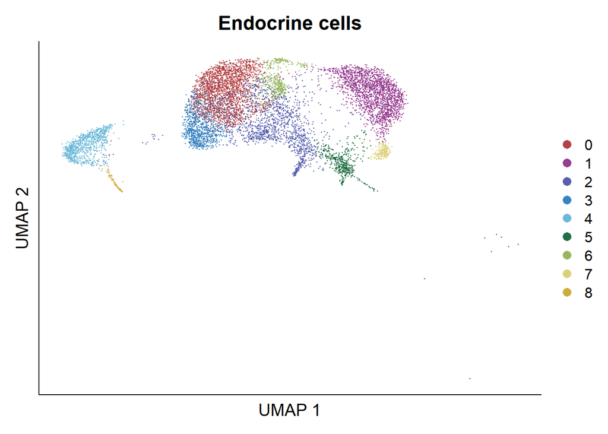

```r
DimPlot(NF_raw, group.by = c("RNA_snn_res.0.35"), cols=colPar) +
  theme(axis.text.x = element_blank(),
        axis.text.y = element_blank(),
        axis.ticks = element_blank(),
        rect = element_blank()) +
  xlab("UMAP 1") + ylab("UMAP 2") + ggtitle("Endocrine cells")
```

```r
table(NF_raw$RNA_snn_res.0.35)
```

```
##
##    0    1    2    3    4    5    6    7    8
## 2130 1972 1512 1007  890  474  430  200   90
```

# 4 Use InferCNV to obtain a CNV heatmap and the CNV score

**Note**: For the inferCNV package, we refer to https://github.com/broadinstitute/inferCNV.

## 4.1 Run infercnv

**Note:** The following `infercnv::run` program will take up large memory and much time (almost 1 day for the following code). You’d better apply for a node with large memory (I suggest 100GB memory) to run the program. Also, the default output will take up large disk space. Here we need to prepare a gene sequence file, download it from the following: https://support.10xgenomics.com/single-cell-gene-expression/software/downloads/latest

```r
library(infercnv)

celltype <- "endocrine"

PCids <- c("S7","S13","S14","S15","S17","S22","S23","S24","S6","S9","S11","S12","S10","S25")
datapath <- "./Data/PCsamples"

i <- 1

commongenes <- list()
for (PCid in PCids){
  PCobj <- readRDS(file.path(datapath,PCid,paste0(PCid,"_clustered_dim20_res0_3.rds")))
  print(dim(PCobj@assays$RNA@counts))
  commongenes[[i]] <- rownames(PCobj)
  i <- i+1
}
commongenes <- Reduce(intersect,commongenes)
commongenes <- intersect(commongenes,rownames(NF))

##### build "raw_counts_matrix"
PC_rawcounts <- c()
for (PCid in PCids){
  PCobj <- readRDS(file.path(datapath,PCid,paste0(PCid,"_clustered_dim20_res0_3.rds")))
  print(PCid)
  load(file.path(datapath,PCid,paste0(PCid,"_cluster_dim20_res0_3_indiv_cell_label.rdata")))
  sc_indiv_cell_label <- as.character(sc_indiv_cell_label)
  if (celltype=="endocrine") sc_indiv_cell_label[sc_indiv_cell_label=="endocrine(beta)"] = celltype
  if (sum(sc_indiv_cell_label == celltype)){
    PC_rawcounts <- cbind(PC_rawcounts,PCobj@assays$RNA@counts[commongenes,sc_indiv_cell_label == celltype])
  }
}

NF_rawcounts <- NF_raw@assays$RNA@counts[commongenes,]
raw_counts_matrix <- cbind(PC_rawcounts,NF_rawcounts)

## build "annotations_file"
PC_annotations <- rep(paste0(celltype,"_PC"),ncol(PC_rawcounts))
NF_annotations <- rep(paste0(celltype),ncol(NF_rawcounts))
annotations_file <- as.data.frame(c(as.character(PC_annotations),as.character(NF_annotations)))
colnames(PC_rawcounts) <- make.names(colnames(PC_rawcounts), unique=T)
rownames(annotations_file) <- c(colnames(PC_rawcounts),colnames(NF_rawcounts))

## read "gene_order_file"
gene_order_file=read.table("./Data/refdata-gex-GRCh38-2020-A/geneOrderingFile.txt",row.names=1)

infercnv_obj = CreateInfercnvObject(raw_counts_matrix=raw_counts_matrix,
                                    annotations_file=annotations_file,
                                    delim="\t",
                                    gene_order_file=gene_order_file,
                                    ref_group_names=c(paste0(celltype,"_PC")))

rm(list=ls()[!ls() %in% c("infercnv_obj")])
gc()

# perform infercnv operations to reveal cnv signal
infercnv_obj = infercnv::run(infercnv_obj,
                             cutoff=0.1,
                             out_dir="./Data/InferCNV_NFEndocrineVsPCEndocrine",  # dir is auto-created for storing outputs
                             cluster_by_groups=T,
                             denoise=T,
                             HMM=T,
                             output_format="pdf"
                             )
```

## 4.2 Compute CNV score

**Note:** You may refer to https://github.com/broadinstitute/infercnv/issues/393 for the discussion on how to compute CNV score. We can get the modified gene expression values `infercnv.references.txt` for reference cells and `infercnv.observations.txt` for observation cells in the output. To obtain the CNV score for each cell, we adopted a method different than that in the discussion:
$$\text{CNV score}_{\text{cell }i} = \sum_j |
\text{Gene expression}_{\text{cell } i,j} - 1 |.$$

```r
obs = read.table("./Data/cnv/infercnv.observations.txt")
refs = read.table("./Data/cnv/infercnv.references.txt")

obs <- obs-1
refs <- refs-1
score_obs <- colSums(abs(obs))
names(score_obs) <- unlist(lapply(strsplit(names(score_obs),'\\.'),function(x) Reduce(function(y,z) paste(y,z,sep='-'),x)))
score_refs =  colSums(abs(refs))
```

## 4.3 Plot with CNV scores

```r
cells = colnames(NF_raw)
ind = match( cells,names(score_obs))
score_obs1 = score_obs [ind ]
identical(names(score_obs1) ,cells)
```

```
## [1] TRUE
```

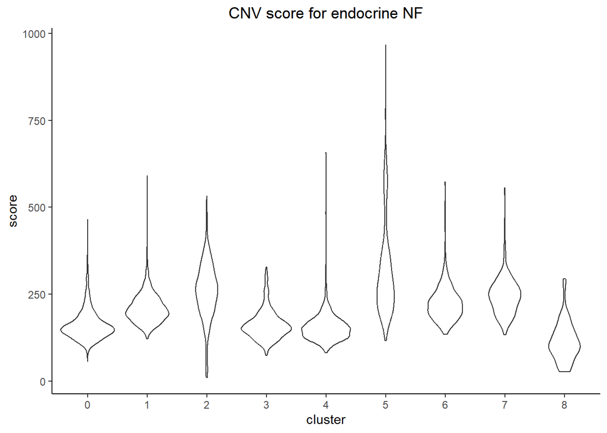

```r
NF_raw$CNVscore = score_obs1

df = data.frame(score = NF_raw$CNVscore,cluster= NF_raw $RNA_snn_res.0.35)

cnv_score_cluster = ggplot(df,aes(x=cluster,y=score, group=cluster)) + geom_violin()  + geom_violin() + ggtitle("CNV score for endocrine NF") + theme(axis.line = element_line(colour = "black"),
                                                                                                                                  panel.grid.major = element_blank(),
                                                                                                                                  panel.grid.minor = element_blank(),
                                                                                                                                  panel.border = element_blank(),
                                                                                                                                  panel.background = element_blank(),
                                                                                                                                  plot.title = element_text(hjust = 0.5))
cnv_score_cluster
```

## 4.4 Define tumor and normal cells

```r
# the mean CNV score from reference scRNA-seq data from normal pancreases tissue:

mean(score_refs)
```

```
## [1] 98.96354
```

```r
## the mean CNV score from tumor tissue:
mean(score_obs)
```

```
## [1] 202.3687
```

```r
# Definition of normal and tumor endocrine cells according to CNV scoring

sum(score_obs > mean(score_refs))
```

```
## [1] 8543
```

```r
sum(score_obs < mean(score_refs))
```

```
## [1] 162
```

```r
## the tumor and normal endocrine cells

table(NF_raw$Malignant)
```

```
##
## Malignant    Normal
##      8543       162
```

## 4.5 Boxplot for score function

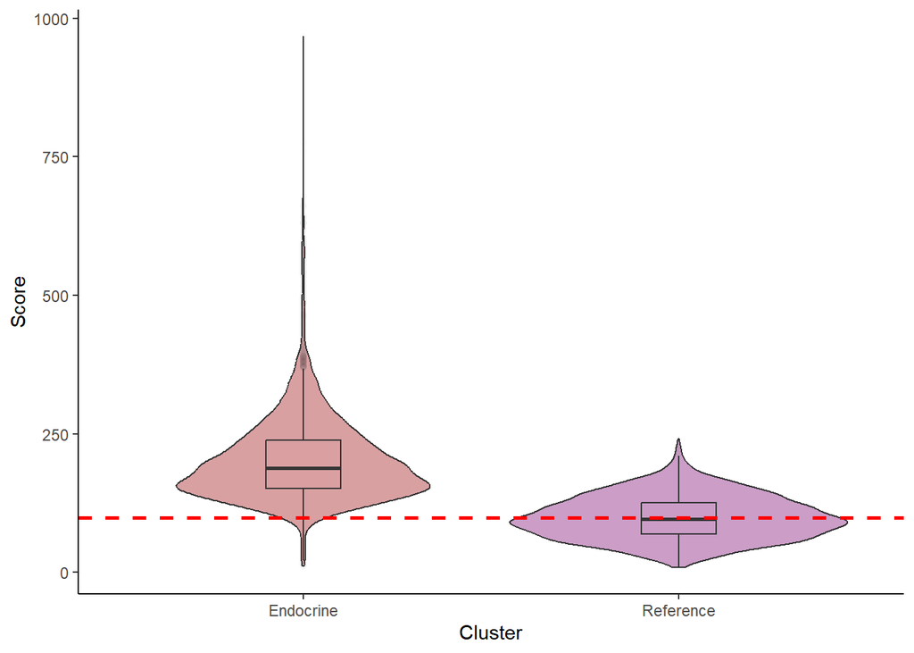

```r
df = data.frame(Score= c(score_refs,score_obs),
                Cluster = c(rep("Reference",length(score_refs)), rep("Endocrine",length(score_obs))))

convertion_ercc <- ggplot(df, aes(x=Cluster,y=Score, group=Cluster,fill = factor(Cluster))
) +
  geom_violin(alpha = .5) +
  geom_boxplot(alpha = .01, width = .2, position = position_dodge(width = .9)) +
  scale_fill_manual(values = colPar )+
  theme(axis.line = element_line(colour = "black"),
        panel.grid.major = element_blank(),
        panel.grid.minor = element_blank(),
        panel.border = element_blank(),
        legend.position = "none",
        panel.background = element_blank(),
        plot.title = element_text(hjust = 0.5))+
  geom_hline(yintercept= mean(score_refs),linetype="dashed",
             color = "red", size=1)
convertion_ercc
```

## 4.6 umap for maligant and normal cell of endocrine cells

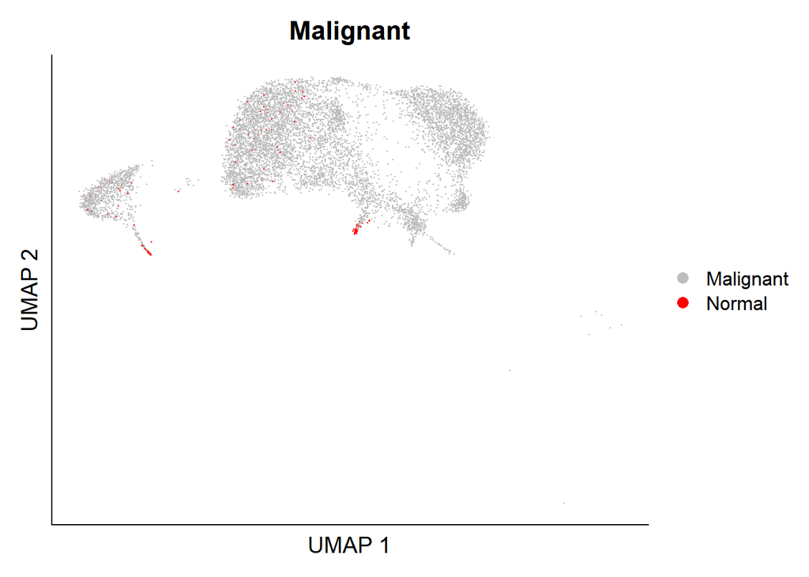

```r
fendocrine = DimPlot(NF_raw, group.by =c("Malignant"), cols = c("gray","red")) +
  theme(axis.text.x = element_blank(),
        axis.text.y = element_blank(),
        axis.ticks = element_blank(),
        rect = element_blank()) +
  xlab("UMAP 1") + ylab("UMAP 2")# + ggtitle("Group By Patients")

fendocrine
```

## 4.7 Fitler cell with only tumor cell and add cell states

```r
table(NF_raw@meta.data$Malignant)
```

```
##
## Malignant    Normal
##      8543       162
```

```r
NF_endoc = NF_raw[, NF_raw@meta.data$Malignant=="Malignant"]

dim(NF_endoc )
```

```
## [1] 27884  8543
```

```r
### add cell type state
unique(NF_endoc@meta.data$RNA_snn_res.0.35)
```

```
## [1] 5 2 3 7 1 0 6 4 8
## Levels: 0 1 2 3 4 5 6 7 8
```

## 4.8 Change cluster name: Subcluster 5 is named “AGR2_high” and the others are named as “AGR2_low”.

```r
subgroup_inf = NF_endoc@meta.data$RNA_snn_res.0.35
cells = colnames(NF_endoc)

subgroup_inf_lable = sort(unique(subgroup_inf))

subgroup_df <- data.frame(ori_ct = subgroup_inf_lable,
                          cha_ct =  c(rep("AGR2_low",5), "AGR2_high",rep("AGR2_low",3)))

temp1 <- match(subgroup_inf ,  subgroup_df$ori_ct)
sample_grade_inf_rename <- subgroup_df $cha_ct[temp1]
subgroup_infor = data.frame(cell = cells, state= sample_grade_inf_rename)
table(subgroup_infor$state)
```

```
##
## AGR2_high  AGR2_low
##       474      8069
```

```r
NF_endoc@meta.data$state = subgroup_infor$state
```

# 5 Draw figures

## 5.1 Figure 2A: tumor endocrine cells

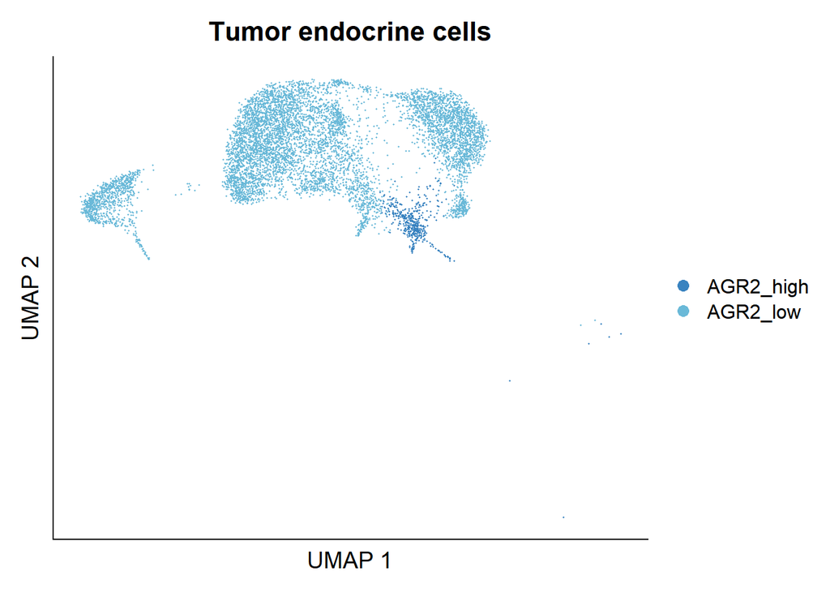

```r
fendocrine = DimPlot(NF_endoc,cols=colPar[4:5], group.by = "state") +
  theme(axis.text.x = element_blank(),
        axis.text.y = element_blank(),
        axis.ticks = element_blank(),
        rect = element_blank()) +
  xlab("UMAP 1") + ylab("UMAP 2")+  ggtitle("Tumor endocrine cells")

fendocrine
```

## 5.2 Figure 2B: barplot with cell type proportion in each sample

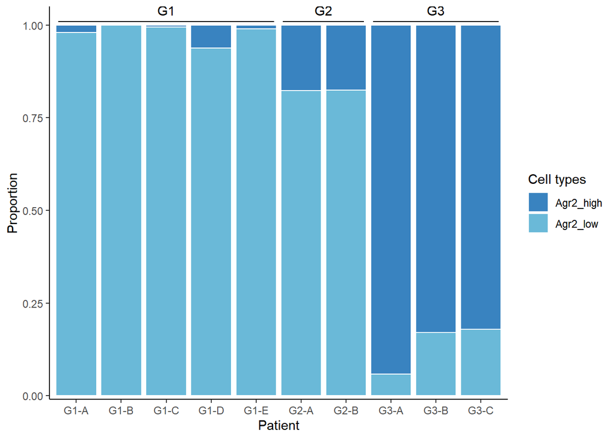

```r
df <- plyr::count(NF_endoc @meta.data[,c("orig.ident","state")])
colnames(df) <- c("Patient","CellType","freq")
df$Patient = factor(df$Patient,
                    levels = names(table(NF_endoc  @meta.data$orig.ident)))
df$CellType = str_to_title(df$CellType)


fsample_prop = ggplot(df,aes(x=Patient, y=freq, fill=CellType)) +
  geom_bar(position="fill",stat="identity",colour="white") + ylab("Proportion") +
  annotate("segment", x = 0.6, xend = 5.4, y = 1.01, yend = 1.01, colour = "black") +
  annotate("text", x = 3, y = 1.04, label = "G1") +
  annotate("segment", x = 5.6, xend = 7.4, y = 1.01, yend = 1.01, colour = "black") +
  annotate("text", x = 6.5, y = 1.04, label = "G2") +
  annotate("segment", x = 7.6, xend = 10.4, y = 1.01, yend = 1.01, colour = "black") +
  annotate("text", x = 9, y = 1.04, label = "G3") +
  scale_y_continuous(expand = c(0,0.01)) +
  scale_fill_manual(values=colPar[4:5])+
  theme_bw() +
  labs(fill="Cell types") +
  theme(axis.line = element_line(colour = "black"),
        panel.grid.major = element_blank(),
        panel.grid.minor = element_blank(),
        panel.border = element_blank(),
        panel.background = element_blank(),
        plot.title = element_text(hjust = 0.5))

fsample_prop
```

## 5.3 Figure 2C: dotplot of the marker genes (with threshold for dotplot)

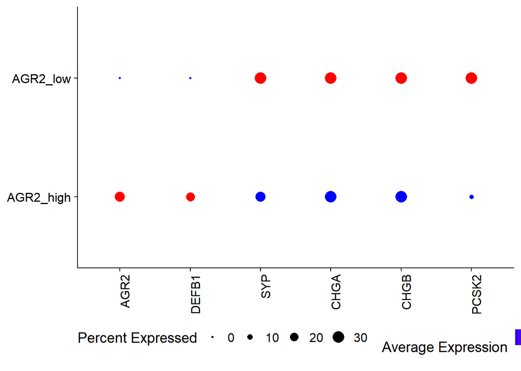

```r
Idents(object = NF_endoc) <- NF_endoc@meta.data$state

gene_list = c("AGR2","DEFB1","SYP", "CHGA", "CHGB",  "PCSK2")

marker_end = DotPlot(NF_endoc, features =gene_list,
                     dot.scale =5,
                     scale.min = -5,
                     scale.max = 30)+
  scale_color_gradient(low="blue", high="red")+
  theme(panel.grid.major = element_blank(),
        panel.grid.minor = element_blank(),
        panel.border = element_blank(),
        panel.background = element_blank(),
        legend.position = "bottom",
        plot.title = element_text(hjust = 0.5),
        axis.title.x =  element_blank(),
        axis.title.y =element_blank(),
        axis.text.y = element_text(hjust=1, size=12),
        axis.text.x = element_text(angle = 90,hjust=1, size=12))
marker_end
```

## 5.4 Figure 2F: CNV score analysis boxplot with wilcox.test

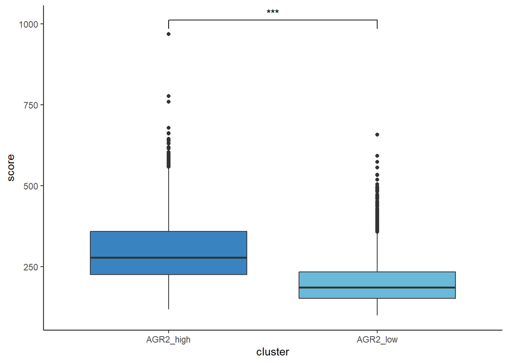

```r
df = data.frame(score= NF_endoc@meta.data$CNVscore,
                cluster = NF_endoc @meta.data$state)
CNVtest = ggplot(df, aes(x=cluster,y=score, group=cluster,fill = factor(cluster))
) +geom_boxplot() +  scale_fill_manual(values = colPar[4:5] )+ theme_bw() +
  geom_signif(comparisons = list(unique(NF_endoc @meta.data$state)), test = "wilcox.test",
              map_signif_level=TRUE) + theme_bw() +
  theme(axis.line = element_line(colour = "black"),
        panel.grid.major = element_blank(),
        panel.grid.minor = element_blank(),
        panel.border = element_blank(),
        panel.background = element_blank(),
        legend.position = "none",
        plot.title = element_text(hjust = 0.5))

CNVtest
```

## 5.5 Figure 2I: gene signatures enrichmented analysis from MLP signature genes.

### 5.5.1 Find Differentially Expressed Genes.

```r
unique(NF_endoc $state)
subset <- NF_endoc [,NF_endoc $state== "AGR2_high" ]

group1 <- sapply(unique(subset$orig.ident),function(patient){if (sum(subset$orig.ident==patient)) rowSums(subset@assays$RNA@counts[,subset$orig.ident==patient,drop=F]) else rep(0,nrow(subset))})

subset <- NF_endoc [,NF_endoc  $state== "AGR2_low" ]
group2 <- sapply(unique(subset$orig.ident),function(patient){if (sum(subset$orig.ident==patient)) rowSums(subset@assays$RNA@counts[,subset$orig.ident==patient,drop=F]) else rep(0,nrow(subset))})

colnames(group1) <- paste0("treated",seq_len(ncol(group1)))
colnames(group2) <- paste0("untreated",seq_len(ncol(group2)))

cts <- as.matrix(cbind(group1,group2))
coldata <- data.frame(condition=c(rep("treated",ncol(group1)),rep("untreated",ncol(group2))))
rownames(coldata) <- colnames(cts)

cts <- cts[rowSums(cts)>0,]
dds <- DESeqDataSetFromMatrix(countData = cts+1,
                              colData = coldata,
                              design = ~ condition)
keep <- rowSums(counts(dds)) >= 10
dds <- dds[keep,]
dds$condition <- factor(dds$condition, levels = c("treated","untreated"))
dds <- DESeq(dds)
res <- results(dds)
res <- as.data.frame(res)

##### compute the expression ratio for each gene and each cluster
group1 <- NF_endoc @assays$RNA@counts[rownames(res),NF_endoc  $state== "AGR2_high" ]
group2 <- NF_endoc @assays$RNA@counts[rownames(res),NF_endoc  $state== "AGR2_low" ]

res <- cbind(res,group1prop=rowSums(group1>0)/ncol(group1),group2prop=rowSums(group2>0)/ncol(group2))

write.csv(res,file=paste0("./Figure2/PseudoBulkDEGs_AGR2_high_vs_AGR2_low.csv"))
```

### 5.5.2 load the data

```r
DEGs = read.table(file=paste0("./Figure2/PseudoBulkDEGs_AGR2_high_vs_AGR2_low.csv"), header = TRUE, sep = ",")

dim(DEGs)
```

```
## [1] 25504     9
```

```r
log2FC = -DEGs$log2FoldChange
names(log2FC) = DEGs$X

geneList = sort(log2FC, decreasing = T)
```

### 5.5.3 Pathway genes for Hanahan_MLP_LIST

```r
### for the pathway genes
pathway_gene = rio::import_list("./Data/pathway/Hanahan_MLP_LIST.xlsx", setclass = "tbl")

names(pathway_gene)
```

```
## [1] "MLP signature"          "IT signature"           "Intermediate signature"
```

```r
#change gene names
i =1
hall_gmt = data.frame(term = rep(names(pathway_gene)[i], length(pathway_gene[[i]]$Gene)),
                      gene = pathway_gene[[i]]$Gene)


gsea1 <- GSEA(geneList = geneList ,   TERM2GENE = hall_gmt,
              pvalueCutoff = 1)
```

```
## preparing geneSet collections...
```

```
## GSEA analysis...
```

```
## leading edge analysis...
```

```
## done...
```

```r
head(gsea1)
```

```
##                          ID   Description setSize enrichmentScore      NES
## MLP signature MLP signature MLP signature      54       0.4792343 2.507983
##                    pvalue    p.adjust qvalue rank                  leading_edge
## MLP signature 5.49356e-07 5.49356e-07     NA 1650 tags=26%, list=6%, signal=24%
##                                                                                   core_enrichment
## MLP signature TOP2A/NDC80/PTTG1/CKS2/SMOC2/KIT/ADAM28/CHST1/THBS2/TWIST1/FCGR1A/LEF1/ENC1/TNFAIP6
```

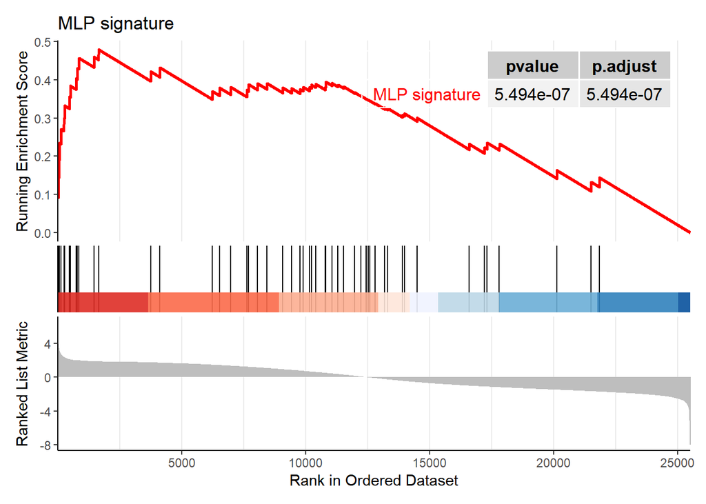

```r
pp =  enrichplot::gseaplot2(gsea1,1, color = "red", title = names(pathway_gene)[i],
                             pvalue_table =T)

pp
```

## Figure 2J-L: Bulk sample analysis **Note:** We first used the cell type deconvolution algorithm Bayesprism to predict the cell type proportion from Bulk RNA-seq data. Then, based on the value of the proportion of AGR2_high cell in each sample, the samples are divided into two groups in proportion to AGR2_high. The default is the median value.

### 5.5.4 the bulk data analysis based on the AGR2_high cells proportion

```r
agr2_outcome_inf = read.csv("./Data/AGR2_Sample_clinical_info.csv")

table(agr2_outcome_inf $agr2HIGH_prop_group)
```

```
##
##  AGR2high_with_larger_proportion AGR2high_with_smaller_proportion
##                               39                               38
```

### 5.5.5 Clinical informations for each groups

```r
names_group = names(table(agr2_outcome_inf $agr2HIGH_prop_group))
names_group
```

```
## [1] "AGR2high_with_larger_proportion"  "AGR2high_with_smaller_proportion"
```

```r
highAGR2_high = agr2_outcome_inf[agr2_outcome_inf$agr2HIGH_prop_group== names_group[1],]
lowAGR2_high = agr2_outcome_inf[agr2_outcome_inf$agr2HIGH_prop_group== names_group[2],]

cat("G grade for two groups","\n" )
```

```
## G grade for two groups
```

```r
table(highAGR2_high$G_grade)
```

```
##
##  1  2  3
##  7 23  9
```

```r
table(lowAGR2_high $G_grade)
```

```
##
##  1  2  3
## 18 17  3
```

```r
cat("Progression_in_3_years","\n" )
```

```
## Progression_in_3_years
```

```r
table(highAGR2_high$Progression_in_3_years)
```

```
##
##  0  1
## 30  9
```

```r
table(lowAGR2_high $Progression_in_3_years)
```

```
##
##  0  1
## 35  3
```

```r
cat("tumor size 40mm","\n" )
```

```
## tumor size 40mm
```

```r
#tumor size 40mm
sum(highAGR2_high$Tumor_size < 20)
```

```
## [1] 3
```

```r
sum(highAGR2_high$Tumor_size >= 20 & highAGR2_high$Tumor_size < 40)
```

```
## [1] 21
```

```r
sum(highAGR2_high$Tumor_size >= 40)
```

```
## [1] 15
```

```r
#tumor size 40mm
sum(lowAGR2_high$Tumor_size < 20)
```

```
## [1] 12
```

```r
sum(lowAGR2_high$Tumor_size >= 20 & lowAGR2_high$Tumor_size < 40)
```

```
## [1] 19
```

```r
sum(lowAGR2_high$Tumor_size >= 40)
```

```
## [1] 7
```

## 5.6 Figure 2J: Tumor size analysis

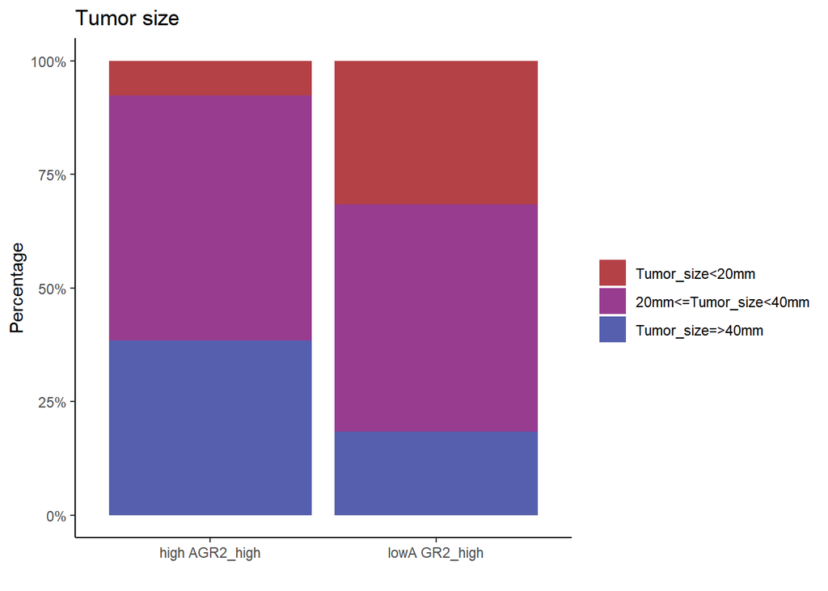

```r
data <- data.frame(
  Category = rep(c("high AGR2_high","lowA GR2_high"), each = 3),
  Group = rep(c("Tumor_size<20mm","20mm<=Tumor_size<40mm","Tumor_size=>40mm"),  2),
  Value = c(sum(highAGR2_high$Tumor_size<20),sum(highAGR2_high$Tumor_size>=20&highAGR2_high$Tumor_size<40),
            length(highAGR2_high$Tumor_size)-sum(highAGR2_high$Tumor_size<40),
            sum(lowAGR2_high$Tumor_size<20),sum(lowAGR2_high$Tumor_size>=20&lowAGR2_high$Tumor_size<40),
            length(lowAGR2_high$Tumor_size)-sum(lowAGR2_high$Tumor_size<40))
)
data$Group = factor(data$Group, levels = c("Tumor_size<20mm","20mm<=Tumor_size<40mm","Tumor_size=>40mm") )

# Create the bar plot with proportions
p3<- ggplot(data, aes(x = Category, y = Value, fill = Group)) +
  geom_col(position = "fill") +  theme_classic()+
  scale_y_continuous(labels = scales::percent_format()) +
  scale_fill_manual(values = colPar) +
  #theme(legend.position = "none")+
  labs(title = "Tumor size",
       x = " ",
       y = "Percentage",
       fill = " ")

# Display the plot
print(p3)
```

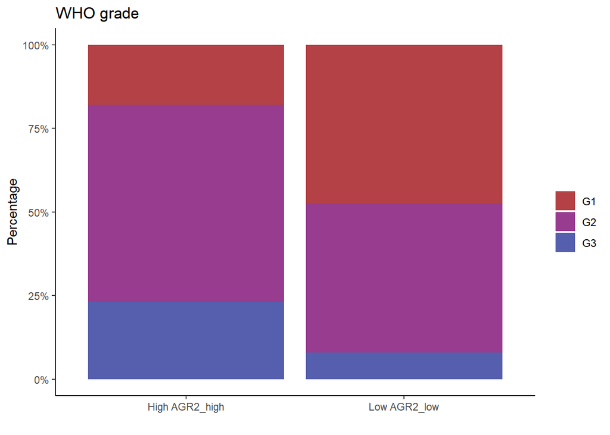

```r
data <- data.frame(
  Category = rep(c("High AGR2_high","Low AGR2_low"),each = 3),
  Group = paste0("G", c(names(table(highAGR2_high$G_grade)), names(table(lowAGR2_high $G_grade)))),
  Value = c(table(highAGR2_high$G_grade),table(lowAGR2_high $G_grade))
)

p1 <- ggplot(data, aes(x = Category, y = Value, fill = Group)) +
  geom_col(position = "fill") +   theme_classic()+
  scale_y_continuous(labels = scales::percent_format()) +
  scale_fill_manual(values = colPar) +  #theme(legend.position = "none")+
  labs(title = "WHO grade",
       x = " ",
       y = "Percentage",
       fill = " ")

# Display the plot
print(p1)
```

### 5.7.1 chi-square test between two groups

```r
cat("G grade for two groups","\n" )
```

```
## G grade for two groups
```

```r
G_grade.data = rbind(c(sum(table(highAGR2_high$G_grade)[1:2]),sum(table(highAGR2_high$G_grade)[3])),
                     c  (sum(table(lowAGR2_high$G_grade)[1:2]),sum(table(lowAGR2_high$G_grade)[3])))
G_grade.data
```

```
##      [,1] [,2]
## [1,]   30    9
## [2,]   35    3
```

```r
chisq.test(G_grade.data)
```

```
##
##  Pearson's Chi-squared test with Yates' continuity correction
##
## data:  G_grade.data
## X-squared = 2.3169, df = 1, p-value = 0.128
```

```r
fisher.test(G_grade.data)
```

```
##
##  Fisher's Exact Test for Count Data
##
## data:  G_grade.data
## p-value = 0.1141
## alternative hypothesis: true odds ratio is not equal to 1
## 95 percent confidence interval:
##  0.04633994 1.30174381
## sample estimates:
## odds ratio
##  0.2902159
```

```r
cat("tumor size 40mm","\n" )
```

```
## tumor size 40mm
```

```r
#tumor size 40mm

Tumor_size.data = rbind(c(sum(highAGR2_high$Tumor_size<20) ,
                          sum(highAGR2_high $Tumor_size>=20 &highAGR2_high $Tumor_size<40),
                          sum(table(highAGR2_high$G_grade)) - sum(highAGR2_high$Tumor_size<40) ),
                        c(sum(lowAGR2_high$Tumor_size<20) ,
                          sum(lowAGR2_high $Tumor_size>=20 &lowAGR2_high $Tumor_size<40),
                          sum(table(lowAGR2_high$G_grade)) - sum(lowAGR2_high$Tumor_size<40) ))

Tumor_size.data
```

```
##      [,1] [,2] [,3]
## [1,]    3   21   15
## [2,]   12   19    7
```

```r
chisq.test(Tumor_size.data)
```

```
##
##  Pearson's Chi-squared test
##
## data:  Tumor_size.data
## X-squared = 8.3975, df = 2, p-value = 0.01501
```

```r
fisher.test(Tumor_size.data)
```

```
##
##  Fisher's Exact Test for Count Data
##
## data:  Tumor_size.data
## p-value = 0.01387
## alternative hypothesis: two.sided
```

## 5.8 Figure 2L: Progression Free Survival Analysis

```r
unique(agr2_outcome_inf$agr2HIGH_prop_group)
```

```
## [1] "AGR2high_with_larger_proportion"  "AGR2high_with_smaller_proportion"
```

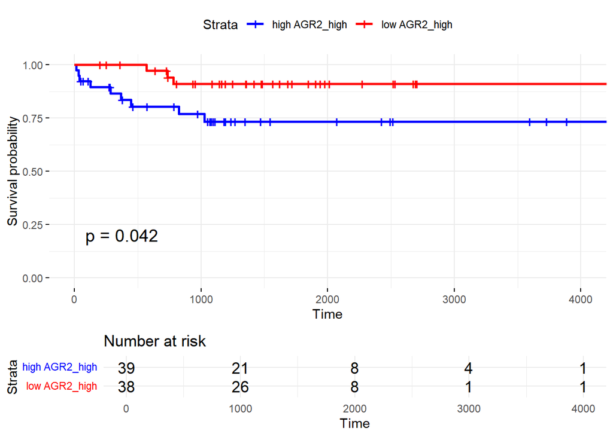

```r
fit<- survfit(Surv(PFS , Progression_in_3_years) ~ agr2HIGH_prop_group, data = agr2_outcome_inf)

p1 = ggsurvplot(fit, data = agr2_outcome_inf,conf.int = FALSE,  # Disable confidence intervals
  ggtheme = theme_minimal(),
  palette = c("blue", "red"),  pval = TRUE,
  legend.labs = c("high AGR2_high", "low AGR2_high"),
  risk.table = TRUE )
p1
```